# act_report

## Report: act_report

#### 1) Most Preferable Dog Stage

The most preffered dog stage is pupper!! The least preffered dog stage is floofer.

- pupper 174
- doggo 59
- puppo 27
- floofer 3

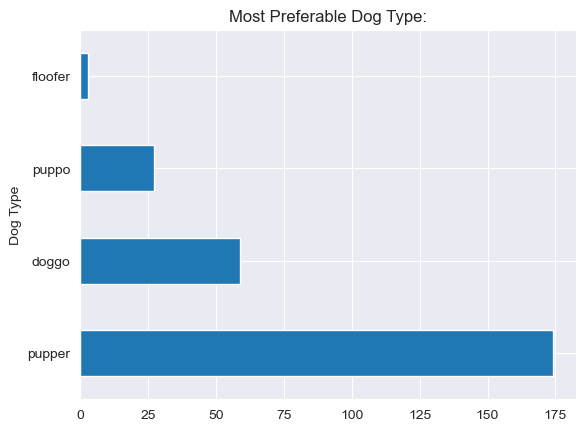

#### 2) Dog Stages according to favorite counts/retweet counts

The favorite count provides the number of times the tweet has been favorited. Retweet is a reposting of a tweet.

Correlation between favorite_count and retweet_count: 0.795 Here the correlation between the favorite and retweet counts is strongly positive.Hence, the trends/insights would be quite similar.

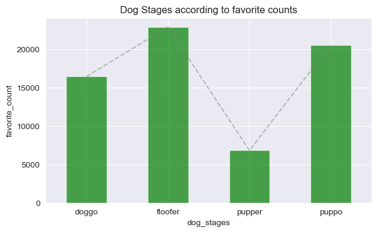

This tells us that according to favorite and retweet counts floofer is the most preffered dog stage, and pupper is the least preffered dog stage according to favorite and retweet counts.

#### 3) Most preffered Dog Breed is the Golden Retriever

The difference between the preference of the highest (Golden Retriever) and the second highest(Labrodor retriever) preffered dog breed is quite large.

Chihuahua and Pembroke have almost equal preference.

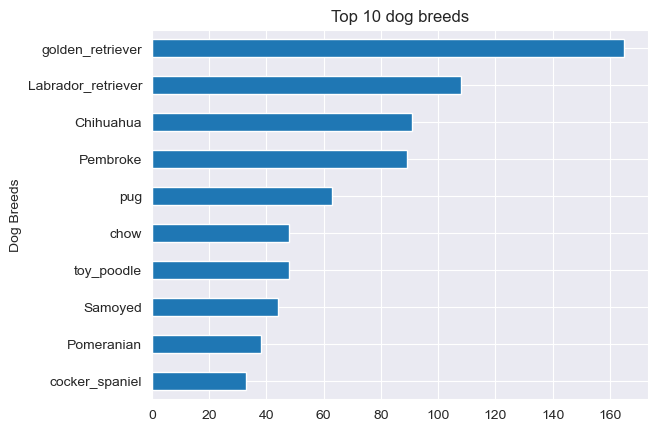

#### 4) Trends from 2015 to 2017 as per the favorite counts

The plot displays that the trend from 2015 to 2017 as per the favorite counts was positively increasing. In the year of 2015 rate of increasing of favorite counts was quite slow. After 2015 the rate of increasing of favorite counts became faster. This could mean that the popularity of the Twitter Account "WeRateDogs" increased rapidly after 2015.

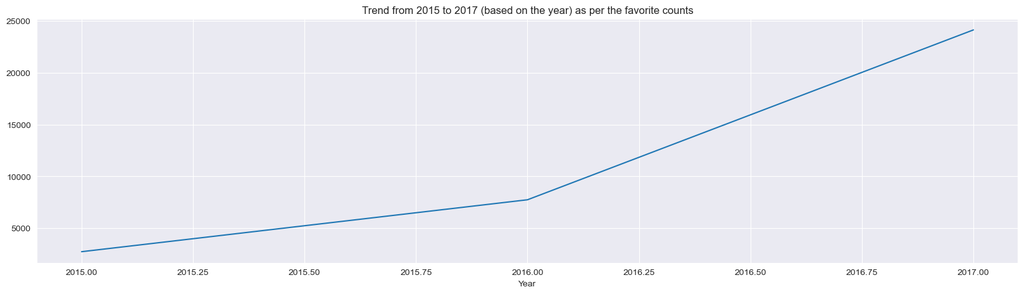

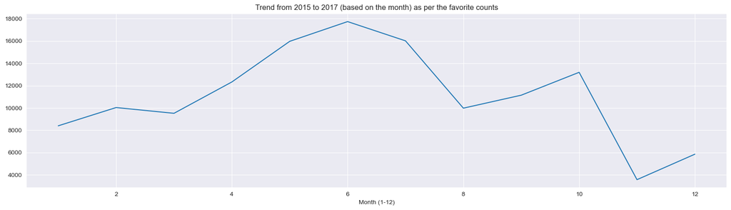

The month June had the highest number of favorite counts and the month November had the lowest number of favorite counts. Note that the months are irrespective of the years("1" means January of 2015, 2016 and 2017)